# udacityproject3_explorationpart1

```python
# import all packages and set plots to be embedded inline
import numpy as np
import pandas as pd
import matplotlib.pyplot as plt
import seaborn as sns

%matplotlib inline
```

```python
#import data
df = pd.read_csv('C:/Users/HP/Documents/python_one_campus/python_workspace/udacityproject3/201902-fordgobike-tripdata.csv')
```

```python
#inspect data visually
df.head()
```

|  | duration_sec | start_time | end_time | start_station_id | start_station_name | start_station_latitude | start_station_longitude | end_station_id | end_station_name | end_station_latitude | end_station_longitude | bike_id | user_type | member_birth_year | member_gender | bike_share_for_all_trip |
| --- | --- | --- | --- | --- | --- | --- | --- | --- | --- | --- | --- | --- | --- | --- | --- | --- |
| 0 | 52185 | 2019-02-28 17:32:10.1450 | 2019-03-01 08:01:55.9750 | 21.0 | Montgomery St BART Station (Market St at 2nd St) | 37.789625 | -122.400811 | 13.0 | Commercial St at Montgomery St | 37.794231 | -122.402923 | 4902 | Customer | 1984.0 | Male | No |
| 1 | 42521 | 2019-02-28 18:53:21.7890 | 2019-03-01 06:42:03.0560 | 23.0 | The Embarcadero at Steuart St | 37.791464 | -122.391034 | 81.0 | Berry St at 4th St | 37.775880 | -122.393170 | 2535 | Customer | NaN | NaN | No |
| 2 | 61854 | 2019-02-28 12:13:13.2180 | 2019-03-01 05:24:08.1460 | 86.0 | Market St at Dolores St | 37.769305 | -122.426826 | 3.0 | Powell St BART Station (Market St at 4th St) | 37.786375 | -122.404904 | 5905 | Customer | 1972.0 | Male | No |
| 3 | 36490 | 2019-02-28 17:54:26.0100 | 2019-03-01 04:02:36.8420 | 375.0 | Grove St at Masonic Ave | 37.774836 | -122.446546 | 70.0 | Central Ave at Fell St | 37.773311 | -122.444293 | 6638 | Subscriber | 1989.0 | Other | No |
| 4 | 1585 | 2019-02-28 23:54:18.5490 | 2019-03-01 00:20:44.0740 | 7.0 | Frank H Ogawa Plaza | 37.804562 | -122.271738 | 222.0 | 10th Ave at E 15th St | 37.792714 | -122.248780 | 4898 | Subscriber | 1974.0 | Male | Yes |

```python
#inspect data programmatically
df.info()
```

```
<class 'pandas.core.frame.DataFrame'>
RangeIndex: 183412 entries, 0 to 183411
Data columns (total 16 columns):
 #   Column                   Non-Null Count   Dtype
---  ------                   --------------   -----
 0   duration_sec             183412 non-null  int64
 1   start_time               183412 non-null  object
 2   end_time                 183412 non-null  object
 3   start_station_id         183215 non-null  float64
 4   start_station_name       183215 non-null  object
 5   start_station_latitude   183412 non-null  float64
 6   start_station_longitude  183412 non-null  float64
 7   end_station_id           183215 non-null  float64
 8   end_station_name         183215 non-null  object
 9   end_station_latitude     183412 non-null  float64
 10  end_station_longitude    183412 non-null  float64
 11  bike_id                  183412 non-null  int64
 12  user_type                183412 non-null  object
 13  member_birth_year        175147 non-null  float64
 14  member_gender            175147 non-null  object
 15  bike_share_for_all_trip  183412 non-null  object
dtypes: float64(7), int64(2), object(7)
memory usage: 22.4+ MB
```

```python
#checking for missing values
df.isna().sum()
```

```
duration_sec                  0
start_time                    0
end_time                      0
start_station_id            197
start_station_name          197
start_station_latitude        0
start_station_longitude       0
end_station_id              197
end_station_name            197
end_station_latitude          0
end_station_longitude         0
bike_id                       0
user_type                     0
member_birth_year          8265
member_gender              8265
bike_share_for_all_trip       0
dtype: int64
```

```python
#checking data distribution and description
df.describe()
```

|  | duration_sec | start_station_id | start_station_latitude | start_station_longitude | end_station_id | end_station_latitude | end_station_longitude | bike_id | member_birth_year |
| --- | --- | --- | --- | --- | --- | --- | --- | --- | --- |
| count | 183412.000000 | 183215.000000 | 183412.000000 | 183412.000000 | 183215.000000 | 183412.000000 | 183412.000000 | 183412.000000 | 175147.000000 |
| mean | 726.078435 | 138.590427 | 37.771223 | -122.352664 | 136.249123 | 37.771427 | -122.352250 | 4472.906375 | 1984.806437 |
| std | 1794.389780 | 111.778864 | 0.099581 | 0.117097 | 111.515131 | 0.099490 | 0.116673 | 1664.383394 | 10.116689 |
| min | 61.000000 | 3.000000 | 37.317298 | -122.453704 | 3.000000 | 37.317298 | -122.453704 | 11.000000 | 1878.000000 |
| 25% | 325.000000 | 47.000000 | 37.770083 | -122.412408 | 44.000000 | 37.770407 | -122.411726 | 3777.000000 | 1980.000000 |
| 50% | 514.000000 | 104.000000 | 37.780760 | -122.398285 | 100.000000 | 37.781010 | -122.398279 | 4958.000000 | 1987.000000 |
| 75% | 796.000000 | 239.000000 | 37.797280 | -122.286533 | 235.000000 | 37.797320 | -122.288045 | 5502.000000 | 1992.000000 |
| max | 85444.000000 | 398.000000 | 37.880222 | -121.874119 | 398.000000 | 37.880222 | -121.874119 | 6645.000000 | 2001.000000 |

```python
#checking the data types
df.dtypes
```

```
duration_sec                 int64
start_time                  object
end_time                    object
start_station_id           float64
start_station_name          object
start_station_latitude     float64
start_station_longitude    float64
end_station_id             float64
end_station_name            object
end_station_latitude       float64
end_station_longitude      float64
bike_id                      int64
user_type                   object
member_birth_year          float64
member_gender               object
bike_share_for_all_trip     object
dtype: object
```

```python
df.columns
```

```
Index(['duration_sec', 'start_time', 'end_time', 'start_station_id',
       'start_station_name', 'start_station_latitude',
       'start_station_longitude', 'end_station_id', 'end_station_name',
       'end_station_latitude', 'end_station_longitude', 'bike_id', 'user_type',
       'member_birth_year', 'member_gender', 'bike_share_for_all_trip'],
      dtype='object')
```

## The quality issues noted and the extraction or transformation that needs to be done

duration_sec - fine as integer, and it can be further converted to hours and minutes

start_time - should be date time , date (day and month) and time(hour) can be extracted

end_time - should be date time, date (day and month) and time (hour) can be extracted

start_station_id - should be object

start_station_name - fine as object

start_station_latitude - fine as float64

start_station_longitude - fine as float64

end_station_id - should be object

end_station_name- fine as object

end_station_latitude -fine as float64

end_station_longitude - fine as float64

bike_id- should be object

user_type - should be category

member_birth_year - fine as integer, age can be extracted from it

member_gender - should be category

bike_share_for_all_trip - should be category

Missing values will be dropped for start_station_id, start_station_name, start_station_id, start_station_name, member_birth_year, member_gender because they can't be replaced and the amount is insignificant compared to the whole dataset(about 4.5%)

```python
#before going ahead to clean make a copy of the original dataset
dfClean = df.copy()
```

```python
#extract columns of hours and minutes from duration_sec

#code
dfClean['duration_min'] = dfClean['duration_sec']/60
dfClean['duration_hr'] = dfClean['duration_sec']/3600

#test
dfClean.head()
```

|  | duration_sec | start_time | end_time | start_station_id | start_station_name | start_station_latitude | start_station_longitude | end_station_id | end_station_name | end_station_latitude | end_station_longitude | bike_id | user_type | member_birth_year | member_gender | bike_share_for_all_trip | duration_min | duration_hr |
| --- | --- | --- | --- | --- | --- | --- | --- | --- | --- | --- | --- | --- | --- | --- | --- | --- | --- | --- |
| 0 | 52185 | 2019-02-28 17:32:10.1450 | 2019-03-01 08:01:55.9750 | 21.0 | Montgomery St BART Station (Market St at 2nd St) | 37.789625 | -122.400811 | 13.0 | Commercial St at Montgomery St | 37.794231 | -122.402923 | 4902 | Customer | 1984.0 | Male | No | 869.750000 | 14.495833 |
| 1 | 42521 | 2019-02-28 18:53:21.7890 | 2019-03-01 06:42:03.0560 | 23.0 | The Embarcadero at Steuart St | 37.791464 | -122.391034 | 81.0 | Berry St at 4th St | 37.775880 | -122.393170 | 2535 | Customer | NaN | NaN | No | 708.683333 | 11.811389 |
| 2 | 61854 | 2019-02-28 12:13:13.2180 | 2019-03-01 05:24:08.1460 | 86.0 | Market St at Dolores St | 37.769305 | -122.426826 | 3.0 | Powell St BART Station (Market St at 4th St) | 37.786375 | -122.404904 | 5905 | Customer | 1972.0 | Male | No | 1030.900000 | 17.181667 |
| 3 | 36490 | 2019-02-28 17:54:26.0100 | 2019-03-01 04:02:36.8420 | 375.0 | Grove St at Masonic Ave | 37.774836 | -122.446546 | 70.0 | Central Ave at Fell St | 37.773311 | -122.444293 | 6638 | Subscriber | 1989.0 | Other | No | 608.166667 | 10.136111 |
| 4 | 1585 | 2019-02-28 23:54:18.5490 | 2019-03-01 00:20:44.0740 | 7.0 | Frank H Ogawa Plaza | 37.804562 | -122.271738 | 222.0 | 10th Ave at E 15th St | 37.792714 | -122.248780 | 4898 | Subscriber | 1974.0 | Male | Yes | 26.416667 | 0.440278 |

```python
dfClean.info()
```

```
<class 'pandas.core.frame.DataFrame'>
RangeIndex: 183412 entries, 0 to 183411
Data columns (total 18 columns):
 #   Column                   Non-Null Count   Dtype
---  ------                   --------------   -----
 0   duration_sec             183412 non-null  int64
 1   start_time               183412 non-null  object
 2   end_time                 183412 non-null  object
 3   start_station_id         183215 non-null  float64
 4   start_station_name       183215 non-null  object
 5   start_station_latitude   183412 non-null  float64
 6   start_station_longitude  183412 non-null  float64
 7   end_station_id           183215 non-null  float64
 8   end_station_name         183215 non-null  object
 9   end_station_latitude     183412 non-null  float64
 10  end_station_longitude    183412 non-null  float64
 11  bike_id                  183412 non-null  int64
 12  user_type                183412 non-null  object
 13  member_birth_year        175147 non-null  float64
 14  member_gender            175147 non-null  object
 15  bike_share_for_all_trip  183412 non-null  object
 16  duration_min             183412 non-null  float64
 17  duration_hr              183412 non-null  float64
dtypes: float64(9), int64(2), object(7)
memory usage: 25.2+ MB
```

```python
#change start_ime and end_time to datetime

#code
dfClean['start_time'] = pd.to_datetime(dfClean['start_time'])
dfClean['end_time'] = pd.to_datetime(dfClean['end_time'])
```

```python
#test
dfClean.info()
```

```
<class 'pandas.core.frame.DataFrame'>
RangeIndex: 183412 entries, 0 to 183411
Data columns (total 18 columns):
 #   Column                   Non-Null Count   Dtype
---  ------                   --------------   -----
 0   duration_sec             183412 non-null  int64
 1   start_time               183412 non-null  datetime64[ns]
 2   end_time                 183412 non-null  datetime64[ns]
 3   start_station_id         183215 non-null  float64
 4   start_station_name       183215 non-null  object
 5   start_station_latitude   183412 non-null  float64
 6   start_station_longitude  183412 non-null  float64
 7   end_station_id           183215 non-null  float64
 8   end_station_name         183215 non-null  object
 9   end_station_latitude     183412 non-null  float64
 10  end_station_longitude    183412 non-null  float64
 11  bike_id                  183412 non-null  int64
 12  user_type                183412 non-null  object
 13  member_birth_year        175147 non-null  float64
 14  member_gender            175147 non-null  object
 15  bike_share_for_all_trip  183412 non-null  object
 16  duration_min             183412 non-null  float64
 17  duration_hr              183412 non-null  float64
dtypes: datetime64[ns](2), float64(9), int64(2), object(5)
memory usage: 25.2+ MB
```

```python
#extract day, month, hour into separate columns

#code
dfClean['start_day_of_month'] = dfClean['start_time'].dt.day
dfClean['start_weekday'] = dfClean['start_time'].dt.weekday
dfClean['start_weekday_name'] = dfClean['start_time'].dt.day_name()
dfClean['start_month'] = dfClean['start_time'].dt.month
dfClean['start_hour'] = dfClean['start_time'].dt.hour
```

```python
dfClean.head()
```

|  | duration_sec | start_time | end_time | start_station_id | start_station_name | start_station_latitude | start_station_longitude | end_station_id | end_station_name | end_station_latitude | ... | member_birth_year | member_gender | bike_share_for_all_trip | duration_min | duration_hr | start_day_of_month | start_weekday | start_weekday_name | start_month | start_hour |
| --- | --- | --- | --- | --- | --- | --- | --- | --- | --- | --- | --- | --- | --- | --- | --- | --- | --- | --- | --- | --- | --- |
| 0 | 52185 | 2019-02-28 17:32:10.145 | 2019-03-01 08:01:55.975 | 21.0 | Montgomery St BART Station (Market St at 2nd St) | 37.789625 | -122.400811 | 13.0 | Commercial St at Montgomery St | 37.794231 | ... | 1984.0 | Male | No | 869.750000 | 14.495833 | 28 | 3 | Thursday | 2 | 17 |
| 1 | 42521 | 2019-02-28 18:53:21.789 | 2019-03-01 06:42:03.056 | 23.0 | The Embarcadero at Steuart St | 37.791464 | -122.391034 | 81.0 | Berry St at 4th St | 37.775880 | ... | NaN | NaN | No | 708.683333 | 11.811389 | 28 | 3 | Thursday | 2 | 18 |
| 2 | 61854 | 2019-02-28 12:13:13.218 | 2019-03-01 05:24:08.146 | 86.0 | Market St at Dolores St | 37.769305 | -122.426826 | 3.0 | Powell St BART Station (Market St at 4th St) | 37.786375 | ... | 1972.0 | Male | No | 1030.900000 | 17.181667 | 28 | 3 | Thursday | 2 | 12 |
| 3 | 36490 | 2019-02-28 17:54:26.010 | 2019-03-01 04:02:36.842 | 375.0 | Grove St at Masonic Ave | 37.774836 | -122.446546 | 70.0 | Central Ave at Fell St | 37.773311 | ... | 1989.0 | Other | No | 608.166667 | 10.136111 | 28 | 3 | Thursday | 2 | 17 |
| 4 | 1585 | 2019-02-28 23:54:18.549 | 2019-03-01 00:20:44.074 | 7.0 | Frank H Ogawa Plaza | 37.804562 | -122.271738 | 222.0 | 10th Ave at E 15th St | 37.792714 | ... | 1974.0 | Male | Yes | 26.416667 | 0.440278 | 28 | 3 | Thursday | 2 | 23 |

5 rows × 23 columns

```python
#extract day, month, hour into separate columns

#code
dfClean['end_day_of_month'] = dfClean['end_time'].dt.day
dfClean['end_weekday'] = dfClean['end_time'].dt.weekday
dfClean['end_weekday_name'] = dfClean['end_time'].dt.day_name()
dfClean['end_month'] = dfClean['end_time'].dt.month
dfClean['end_hour'] = dfClean['end_time'].dt.hour
```

```python
#test
dfClean.head()
```

|  | duration_sec | start_time | end_time | start_station_id | start_station_name | start_station_latitude | start_station_longitude | end_station_id | end_station_name | end_station_latitude | ... | start_day_of_month | start_weekday | start_weekday_name | start_month | start_hour | end_day_of_month | end_weekday | end_weekday_name | end_month | end_hour |
| --- | --- | --- | --- | --- | --- | --- | --- | --- | --- | --- | --- | --- | --- | --- | --- | --- | --- | --- | --- | --- | --- |
| 0 | 52185 | 2019-02-28 17:32:10.145 | 2019-03-01 08:01:55.975 | 21.0 | Montgomery St BART Station (Market St at 2nd St) | 37.789625 | -122.400811 | 13.0 | Commercial St at Montgomery St | 37.794231 | ... | 28 | 3 | Thursday | 2 | 17 | 1 | 4 | Friday | 3 | 8 |
| 1 | 42521 | 2019-02-28 18:53:21.789 | 2019-03-01 06:42:03.056 | 23.0 | The Embarcadero at Steuart St | 37.791464 | -122.391034 | 81.0 | Berry St at 4th St | 37.775880 | ... | 28 | 3 | Thursday | 2 | 18 | 1 | 4 | Friday | 3 | 6 |
| 2 | 61854 | 2019-02-28 12:13:13.218 | 2019-03-01 05:24:08.146 | 86.0 | Market St at Dolores St | 37.769305 | -122.426826 | 3.0 | Powell St BART Station (Market St at 4th St) | 37.786375 | ... | 28 | 3 | Thursday | 2 | 12 | 1 | 4 | Friday | 3 | 5 |
| 3 | 36490 | 2019-02-28 17:54:26.010 | 2019-03-01 04:02:36.842 | 375.0 | Grove St at Masonic Ave | 37.774836 | -122.446546 | 70.0 | Central Ave at Fell St | 37.773311 | ... | 28 | 3 | Thursday | 2 | 17 | 1 | 4 | Friday | 3 | 4 |
| 4 | 1585 | 2019-02-28 23:54:18.549 | 2019-03-01 00:20:44.074 | 7.0 | Frank H Ogawa Plaza | 37.804562 | -122.271738 | 222.0 | 10th Ave at E 15th St | 37.792714 | ... | 28 | 3 | Thursday | 2 | 23 | 1 | 4 | Friday | 3 | 0 |

5 rows × 28 columns

```python
dfClean.info()
```

```
<class 'pandas.core.frame.DataFrame'>
RangeIndex: 183412 entries, 0 to 183411
Data columns (total 28 columns):
 #   Column                   Non-Null Count   Dtype
---  ------                   --------------   -----
 0   duration_sec             183412 non-null  int64
 1   start_time               183412 non-null  datetime64[ns]
 2   end_time                 183412 non-null  datetime64[ns]
 3   start_station_id         183215 non-null  float64
 4   start_station_name       183215 non-null  object
 5   start_station_latitude   183412 non-null  float64
 6   start_station_longitude  183412 non-null  float64
 7   end_station_id           183215 non-null  float64
 8   end_station_name         183215 non-null  object
 9   end_station_latitude     183412 non-null  float64
```

[output cut: 20 more lines]

```python
# change start_station_id, end_station_id and bike_id to object

#code
dfClean['start_station_id'] = dfClean['start_station_id'].astype(str)
dfClean['end_station_id'] = dfClean['end_station_id'].astype(str)
dfClean['bike_id'] = dfClean['bike_id'].astype(str)
```

```python
#test
dfClean.info()
```

```
<class 'pandas.core.frame.DataFrame'>
RangeIndex: 183412 entries, 0 to 183411
Data columns (total 28 columns):
 #   Column                   Non-Null Count   Dtype
---  ------                   --------------   -----
 0   duration_sec             183412 non-null  int64
 1   start_time               183412 non-null  datetime64[ns]
 2   end_time                 183412 non-null  datetime64[ns]
 3   start_station_id         183412 non-null  object
 4   start_station_name       183215 non-null  object
 5   start_station_latitude   183412 non-null  float64
 6   start_station_longitude  183412 non-null  float64
 7   end_station_id           183412 non-null  object
 8   end_station_name         183215 non-null  object
 9   end_station_latitude     183412 non-null  float64
```

[output cut: 20 more lines]

```python
# change user_type, member_gender and bike_share_for_all_trip to category

#code
dfClean['user_type'] = dfClean['user_type'].astype('category')
dfClean['member_gender'] = dfClean['member_gender'].astype('category')
dfClean['bike_share_for_all_trip'] = dfClean['bike_share_for_all_trip'].astype('category')
```

```python
#test
dfClean.info()
```

```
<class 'pandas.core.frame.DataFrame'>
RangeIndex: 183412 entries, 0 to 183411
Data columns (total 28 columns):
 #   Column                   Non-Null Count   Dtype
---  ------                   --------------   -----
 0   duration_sec             183412 non-null  int64
 1   start_time               183412 non-null  datetime64[ns]
 2   end_time                 183412 non-null  datetime64[ns]
 3   start_station_id         183412 non-null  object
 4   start_station_name       183215 non-null  object
 5   start_station_latitude   183412 non-null  float64
 6   start_station_longitude  183412 non-null  float64
 7   end_station_id           183412 non-null  object
 8   end_station_name         183215 non-null  object
 9   end_station_latitude     183412 non-null  float64
```

[output cut: 20 more lines]

```python
#to extract age from member birth year
from datetime import datetime, date
today = date.today()
```

```python
#code
dfClean['Age'] = today.year - dfClean['member_birth_year']
```

```python
dfClean.head()
```

|  | duration_sec | start_time | end_time | start_station_id | start_station_name | start_station_latitude | start_station_longitude | end_station_id | end_station_name | end_station_latitude | ... | start_weekday | start_weekday_name | start_month | start_hour | end_day_of_month | end_weekday | end_weekday_name | end_month | end_hour | Age |
| --- | --- | --- | --- | --- | --- | --- | --- | --- | --- | --- | --- | --- | --- | --- | --- | --- | --- | --- | --- | --- | --- |
| 0 | 52185 | 2019-02-28 17:32:10.145 | 2019-03-01 08:01:55.975 | 21.0 | Montgomery St BART Station (Market St at 2nd St) | 37.789625 | -122.400811 | 13.0 | Commercial St at Montgomery St | 37.794231 | ... | 3 | Thursday | 2 | 17 | 1 | 4 | Friday | 3 | 8 | 38.0 |
| 1 | 42521 | 2019-02-28 18:53:21.789 | 2019-03-01 06:42:03.056 | 23.0 | The Embarcadero at Steuart St | 37.791464 | -122.391034 | 81.0 | Berry St at 4th St | 37.775880 | ... | 3 | Thursday | 2 | 18 | 1 | 4 | Friday | 3 | 6 | NaN |
| 2 | 61854 | 2019-02-28 12:13:13.218 | 2019-03-01 05:24:08.146 | 86.0 | Market St at Dolores St | 37.769305 | -122.426826 | 3.0 | Powell St BART Station (Market St at 4th St) | 37.786375 | ... | 3 | Thursday | 2 | 12 | 1 | 4 | Friday | 3 | 5 | 50.0 |
| 3 | 36490 | 2019-02-28 17:54:26.010 | 2019-03-01 04:02:36.842 | 375.0 | Grove St at Masonic Ave | 37.774836 | -122.446546 | 70.0 | Central Ave at Fell St | 37.773311 | ... | 3 | Thursday | 2 | 17 | 1 | 4 | Friday | 3 | 4 | 33.0 |
| 4 | 1585 | 2019-02-28 23:54:18.549 | 2019-03-01 00:20:44.074 | 7.0 | Frank H Ogawa Plaza | 37.804562 | -122.271738 | 222.0 | 10th Ave at E 15th St | 37.792714 | ... | 3 | Thursday | 2 | 23 | 1 | 4 | Friday | 3 | 0 | 48.0 |

5 rows × 29 columns

```python
#drop missing values

#code
dfClean.dropna(inplace = True)
```

```python
#test
dfClean.isna().sum()
```

```
duration_sec               0
start_time                 0
end_time                   0
start_station_id           0
start_station_name         0
start_station_latitude     0
start_station_longitude    0
end_station_id             0
end_station_name           0
end_station_latitude       0
end_station_longitude      0
bike_id                    0
user_type                  0
member_birth_year          0
member_gender              0
bike_share_for_all_trip    0
duration_min               0
duration_hr                0
start_day_of_month         0
start_weekday              0
start_weekday_name         0
start_month                0
start_hour                 0
end_day_of_month           0
end_weekday                0
end_weekday_name           0
end_month                  0
end_hour                   0
Age                        0
dtype: int64
```

```python
#to check duplicated values
print(dfClean.duplicated().sum())
```

```
0
```

```python
dfClean.shape
```

```
(174952, 29)
```

### What is/are the main feature(s) of interest in your dataset?

I am interested in how long a trip takes, the kind of users that are involved in the trips, the age groups and genders, the day of the week or time of the day or year the trips are taken and what determines the bike sharing for all trips

### What features in the dataset do you think will help support your investigation into your feature(s) of interest?

I think the duration, start and end time, user type, gender, age and bike share for all trip will help support my invstigation

## Univariate Exploration

```python
#question- to see the distribution of user types

dfClean['user_type'].value_counts()
```

```
Subscriber    158386
Customer       16566
Name: user_type, dtype: int64
```

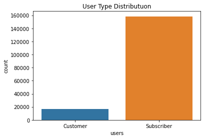

```python
#visualisation
sns.countplot(data = dfClean, x = 'user_type')
plt.title('User Type Distributuon')
plt.xlabel('users')
plt.ylabel('count');
```

Observation- the number of subscribers are way more than the customers

```python
#question- to show the distribution of the duration used in hours over the data set
dfClean['duration_hr'].describe()
```

```
count    174952.000000
mean          0.195556
std           0.456168
min           0.016944
25%           0.089722
50%           0.141667
75%           0.219167
max          23.485556
Name: duration_hr, dtype: float64
```

The maximum hour is really far away from the mean or the mode, the data is most likely skewed

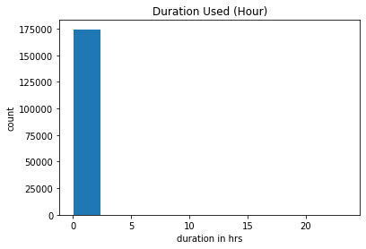

```python
#visualisation

plt.hist(data = dfClean, x = 'duration_hr')
plt.title('Duration Used (Hour)')
plt.xlabel('duration in hrs')
plt.ylabel('count');
```

```python
dfClean['duration_hr'].describe()
```

```
count    174952.000000
mean          0.195556
std           0.456168
min           0.016944
25%           0.089722
50%           0.141667
75%           0.219167
max          23.485556
Name: duration_hr, dtype: float64
```

Observation Like I envisaged, it is skewed and it doesnot really show much, I will expand the number of bins to see how it looks

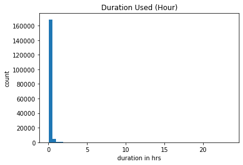

```python
plt.hist(data = dfClean, x = 'duration_hr', bins = 50)
plt.title('Duration Used (Hour)')
plt.xlabel('duration in hrs')
plt.ylabel('count');
```

Observation Just a little difference, still skewed

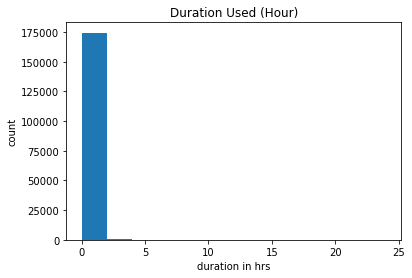

```python
#setting the bins from the data itself
bins = np.arange(0, dfClean['duration_hr'].max()+2, 2)

plt.hist(data = dfClean, x = 'duration_hr', bins = bins)
plt.title('Duration Used (Hour)')
plt.xlabel('duration in hrs')
plt.ylabel('count');
```

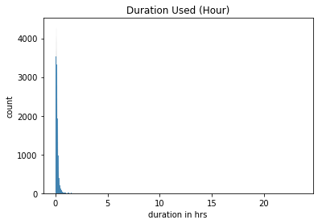

```python
sns.histplot(dfClean['duration_hr'], kde=False)
plt.title('Duration Used (Hour)')
plt.xlabel('duration in hrs')
plt.ylabel('count');
```

```python
#question to check the distibution of the duration in minutes
dfClean['duration_min'].describe()
```

```
count    174952.000000
mean         11.733379
std          27.370082
min           1.016667
25%           5.383333
50%           8.500000
75%          13.150000
max        1409.133333
Name: duration_min, dtype: float64
```

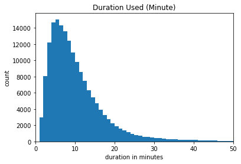

```python
#visualisation
bins = np.arange(0, dfClean['duration_min'].max()+1, 1)

plt.hist(data = dfClean, x = 'duration_min', bins = bins)
plt.xlim([0,50]) #setting the limit to zoom in on the data distribution
plt.title('Duration Used (Minute)')
plt.xlabel('duration in minutes')
plt.ylabel('count');
```

```python
# I will use the log distribution to normalise the data because of its skewness
# Transform the describe() to a scale of log10

np.log10(dfClean['duration_min'].describe())
```

```
count    5.242919
mean     1.069423
std      1.437276
min      0.007179
25%      0.731051
50%      0.929419
75%      1.118926
max      3.148952
Name: duration_min, dtype: float64
```

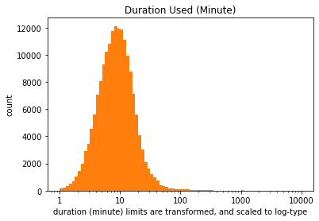

```python
#visualisation
# Bin size
bins = 10 ** np.arange(0, 4+0.05, 0.05)
plt.hist(data = dfClean, x = 'duration_min', bins = bins);

# Generate the x-ticks you want to apply
ticks = [1, 10, 100, 1000, 10000]
# Convert ticks into string values, to be displaye dlong the x-axis
labels = ['{}'.format(v) for v in ticks]

# Plot the histogram
plt.hist(data = dfClean, x = 'duration_min', bins = bins);

plt.xscale('log')

# Apply x-ticks
plt.xticks(ticks, labels)
plt.title('Duration Used (Minute)')
plt.xlabel('duration (minute) limits are transformed, and scaled to log-type')
plt.ylabel('count');
```

observation this looks better and it shows a relatively normal distribution

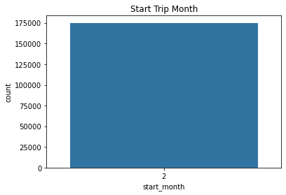

```python
#question - to check the distibution of the start month of the trips

#visualisation
base_color = sns.color_palette()[0]
sns.countplot(data= dfClean, x ='start_month', color = base_color)
plt.title('Start Trip Month')
plt.xlabel('start_month')
plt.ylabel('count');
```

Observation Looks like they all startedtheir trips in the same month which is febraury. Most likely the data set is for this month alone

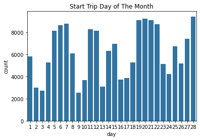

```python
#question to check the number of bike trips based on the start days

#visualisation
sns.countplot(data= dfClean, x ='start_day_of_month', color = base_color)
plt.title('Start Trip Day of The Month')
plt.xlabel('day')
plt.ylabel('count');
```

Observation The last day of the month seems to be the most popular day among bike riders while the 3rd and 9th day have the least popularity

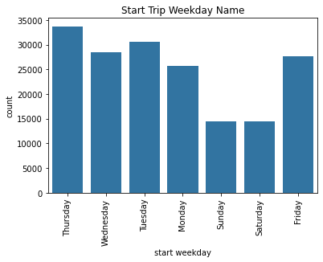

```python
#question to check the frequency of the days of the week among users

#visualisation
sns.countplot(data= dfClean, x ='start_weekday_name', color = base_color)
plt.xticks(rotation = 90)
plt.title('Start Trip Weekday Name')
plt.xlabel('start weekday')
plt.ylabel('count');
```

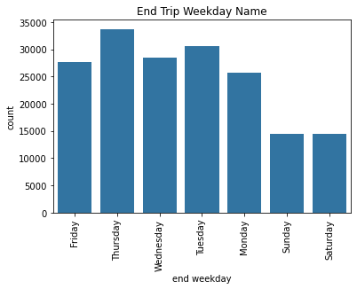

```python
#question to check the frequency of the days of the week among users

#visualisation
sns.countplot(data= dfClean, x ='end_weekday_name', color = base_color)
plt.xticks(rotation = 90)
plt.title('End Trip Weekday Name')
plt.xlabel('end weekday')
plt.ylabel('count');
```

Observation Most people started and ended their trips on thursdays, seems many people prefer not to start trips on saturdays and sundays (weekend)

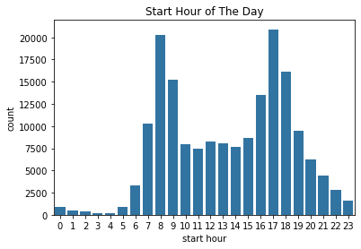

```python
#question to check the frequency of the time of the day among users

#visualisation
sns.countplot(data= dfClean, x ='start_hour', color = base_color)
plt.title('Start Hour of The Day')
plt.xlabel('start hour')
plt.ylabel('count');
```

Observation People love riding most in the evening by 5pm and morning by 8am.

```python
#question is to check the most popular start station used in the trips
dfClean['start_station_name'].value_counts()
```

```
Market St at 10th St                                         3649
San Francisco Caltrain Station 2  (Townsend St at 4th St)    3408
Berry St at 4th St                                           2952
Montgomery St BART Station (Market St at 2nd St)             2711
Powell St BART Station (Market St at 4th St)                 2620
                                                             ...
Farnam St at Fruitvale Ave                                      9
Parker Ave at McAllister St                                     7
21st Ave at International Blvd                                  4
Palm St at Willow St                                            3
16th St Depot                                                   2
Name: start_station_name, Length: 329, dtype: int64
```

Market St at 10th St is the highest used and 16th St Depot is the lowest

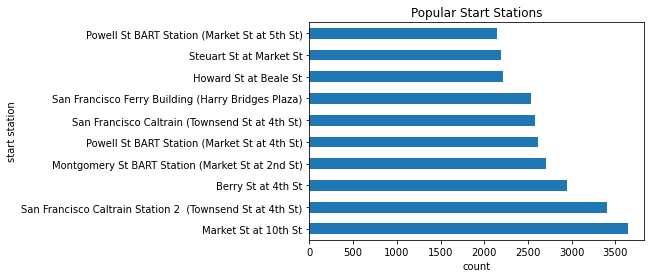

```python
#visualisation
dfClean['start_station_name'].value_counts().sort_values(ascending = False).head(10).plot.barh();
plt.title('Popular Start Stations')
plt.xlabel('count')
plt.ylabel('start station')
plt.show;
```

Observation The 10 most used start station from lowest to highest is shown

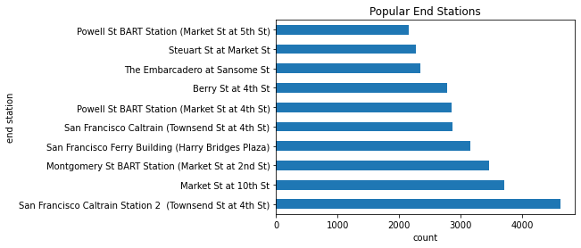

```python
#question is to check the most popular start station used in the trips

#visualisation
dfClean['end_station_name'].value_counts().sort_values(ascending = False).head(10).plot.barh()
plt.title('Popular End Stations')
plt.xlabel('count')
plt.ylabel('end station')
plt.show();
```

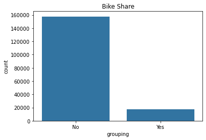

```python
#question to check the frequrncy of bike share for all trips

#visualisation
sns.countplot(data= dfClean, x ='bike_share_for_all_trip', color = base_color)
plt.title('Bike Share')
plt.xlabel('grouping')
plt.ylabel('count');
```

Observation Most people are not fans of sharing their bike trips

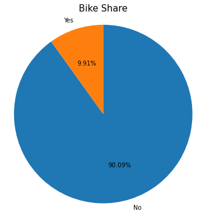

```python
#question to check the percentage of bike share for all trips

#visualisation
plt.figure(figsize=(10,6))
sorted_counts = dfClean['bike_share_for_all_trip'].value_counts()

plt.pie(sorted_counts, labels = sorted_counts.index, startangle = 90,
        counterclock = False, autopct='%1.2f%%')
plt.axis('square')
plt.title('Bike Share', fontsize=15);
```

Observation About 90% do not share their trips, out of 10 people, only 1 would share

```python
#question to check the distribution of age of the users
dfClean['Age'].describe()
```

```
count    174952.000000
mean         37.196865
std          10.118731
min          21.000000
25%          30.000000
50%          35.000000
75%          42.000000
max         144.000000
Name: Age, dtype: float64
```

Observation The maximum age here is 144, which is surprising, isn't that person too old??

```python
outliers = dfClean['Age'] > 100
```

```python
dfClean[outliers]
```

|  | duration_sec | start_time | end_time | start_station_id | start_station_name | start_station_latitude | start_station_longitude | end_station_id | end_station_name | end_station_latitude | ... | start_weekday | start_weekday_name | start_month | start_hour | end_day_of_month | end_weekday | end_weekday_name | end_month | end_hour | Age |
| --- | --- | --- | --- | --- | --- | --- | --- | --- | --- | --- | --- | --- | --- | --- | --- | --- | --- | --- | --- | --- | --- |
| 1285 | 148 | 2019-02-28 19:29:17.627 | 2019-02-28 19:31:45.967 | 158.0 | Shattuck Ave at Telegraph Ave | 37.833279 | -122.263490 | 173.0 | Shattuck Ave at 55th St | 37.840364 | ... | 3 | Thursday | 2 | 19 | 28 | 3 | Thursday | 2 | 19 | 122.0 |
| 10827 | 1315 | 2019-02-27 19:21:34.436 | 2019-02-27 19:43:30.008 | 343.0 | Bryant St at 2nd St | 37.783172 | -122.393572 | 375.0 | Grove St at Masonic Ave | 37.774836 | ... | 2 | Wednesday | 2 | 19 | 27 | 2 | Wednesday | 2 | 19 | 122.0 |
| 16087 | 1131 | 2019-02-27 08:37:36.864 | 2019-02-27 08:56:28.022 | 375.0 | Grove St at Masonic Ave | 37.774836 | -122.446546 | 36.0 | Folsom St at 3rd St | 37.783830 | ... | 2 | Wednesday | 2 | 8 | 27 | 2 | Wednesday | 2 | 8 | 122.0 |
| 17981 | 366 | 2019-02-26 19:53:38.528 | 2019-02-26 19:59:44.968 | 50.0 | 2nd St at Townsend St | 37.780526 | -122.390288 | 21.0 | Montgomery St BART Station (Market St at 2nd St) | 37.789625 | ... | 1 | Tuesday | 2 | 19 | 26 | 1 | Tuesday | 2 | 19 | 102.0 |
| 18885 | 432 | 2019-02-26 17:48:59.016 | 2019-02-26 17:56:11.370 | 21.0 | Montgomery St BART Station (Market St at 2nd St) | 37.789625 | -122.400811 | 50.0 | 2nd St at Townsend St | 37.780526 | ... | 1 | Tuesday | 2 | 17 | 26 | 1 | Tuesday | 2 | 17 | 102.0 |
| ... | ... | ... | ... | ... | ... | ... | ... | ... | ... | ... | ... | ... | ... | ... | ... | ... | ... | ... | ... | ... | ... |
| 171996 | 1368 | 2019-02-03 17:33:54.607 | 2019-02-03 17:56:42.949 | 37.0 | 2nd St at Folsom St | 37.785000 | -122.395936 | 375.0 | Grove St at Masonic Ave | 37.774836 | ... | 6 | Sunday | 2 | 17 | 3 | 6 | Sunday | 2 | 17 | 122.0 |
| 173711 | 993 | 2019-02-03 09:45:30.464 | 2019-02-03 10:02:04.169 | 375.0 | Grove St at Masonic Ave | 37.774836 | -122.446546 | 36.0 | Folsom St at 3rd St | 37.783830 | ... | 6 | Sunday | 2 | 9 | 3 | 6 | Sunday | 2 | 10 | 122.0 |
| 177708 | 1527 | 2019-02-01 19:09:28.387 | 2019-02-01 19:34:55.963 | 343.0 | Bryant St at 2nd St | 37.783172 | -122.393572 | 375.0 | Grove St at Masonic Ave | 37.774836 | ... | 4 | Friday | 2 | 19 | 1 | 4 | Friday | 2 | 19 | 122.0 |
| 177885 | 517 | 2019-02-01 18:38:40.471 | 2019-02-01 18:47:18.392 | 25.0 | Howard St at 2nd St | 37.787522 | -122.397405 | 30.0 | San Francisco Caltrain (Townsend St at 4th St) | 37.776598 | ... | 4 | Friday | 2 | 18 | 1 | 4 | Friday | 2 | 18 | 120.0 |
| 182830 | 428 | 2019-02-01 07:45:05.934 | 2019-02-01 07:52:14.922 | 284.0 | Yerba Buena Center for the Arts (Howard St at ... | 37.784872 | -122.400876 | 67.0 | San Francisco Caltrain Station 2 (Townsend St... | 37.776639 | ... | 4 | Friday | 2 | 7 | 1 | 4 | Friday | 2 | 7 | 121.0 |

75 rows × 29 columns

```python
dfClean[dfClean['Age'] == 144].duration_min
```

```
27370    24.566667
Name: duration_min, dtype: float64
```

Observation The duration for the oldest person is a little above twice the average ride duration for the whole population. Well, I expect the person to be slower nd take longer time. Further invsetigation can be done to rechek the age and the type of bike used and the dustance covered

```python
dfClean[outliers].duration_min.mean()
```

```
10.829333333333333
```

Observation People above 100 averegae ride duration is about 11 minutes which is close to the average duration the general population uses

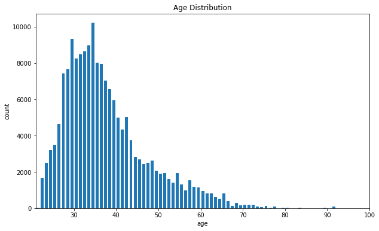

```python
#visualisation of age distribution

plt.figure(figsize=(10,6))
bin_edges = np.arange(21, 144+1, 1)
plt.hist(data = dfClean, x ='Age', bins = bin_edges, rwidth = 0.7)
plt.xlim((21,100)); #I am not including the outliers
plt.title('Age Distribution')
plt.xlabel('age')
plt.ylabel('count');
```

observation The distribution is skewed to the right because most people are young (between 30 to 40 years)

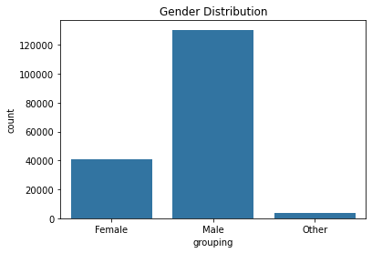

```python
#question to check the frequrncy of gender

#visualisation
sns.countplot(data= dfClean, x ='member_gender', color = base_color)
plt.title('Gender Distribution')
plt.xlabel('grouping')
plt.ylabel('count');
```

Observation Males have the highest number, seems they really enjoy riding more than the other genders

## Univariate

### Of the features you investigated, were there any unusual distributions? Did you perform any operations on the data to tidy, adjust, or change the form of the data? If so, why did you do this?

I had to clean the data and change some data types and extract further information from the givend data

## Bivariate

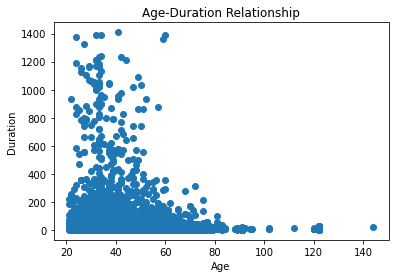

```python
#to check the realtionship between age distribution and the duration spent on a bike ride

# visualisation Scatter plot
plt.scatter(data = dfClean, x = 'Age', y = 'duration_min');
plt.xlabel('Age')
plt.ylabel('Duration')
plt.title('Age-Duration Relationship');
```

Observation I don't think there is any correlation

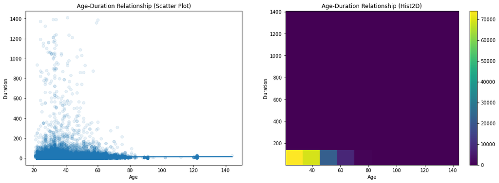

```python
plt.figure(figsize = [18, 6])

# PLOT ON LEFT
plt.subplot(1, 2, 1)
sns.regplot(data = dfClean, x = 'Age', y = 'duration_min', x_jitter = 0.04, scatter_kws = {'alpha':1/10}, fit_reg= True)
plt.xlabel('Age')
plt.ylabel('Duration')
plt.title('Age-Duration Relationship (Scatter Plot)');

# PLOT ON RIGHT
plt.subplot(1, 2, 2)
plt.hist2d(data = dfClean, x = 'Age', y = 'duration_min')
plt.colorbar()
plt.xlabel('Age')
plt.ylabel('Duration')
plt.title('Age-Duration Relationship (Hist2D)');
```

Observation Most of the riders are concentrated at the lower left quandrant of the plot, they are younger and spend less number of minutes on their rides. Some young people are noticed to spend more time while older people are noticed to spend less time on their rides, The kind of bikes used and the distance covered can also be investigated to see why that is

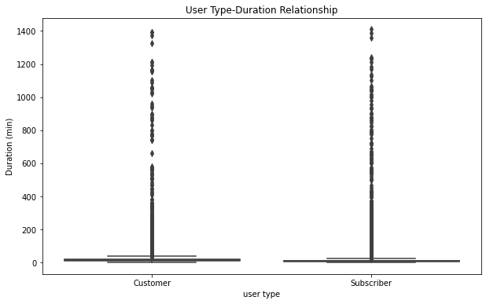

```python
#Question to check the distribution of user types over the duration spent on bike rides

#visualisation
plt.figure(figsize=(10,6))
sns.boxplot(data = dfClean, x='user_type', y='duration_min', color = base_color)
plt.xlabel('user type')
plt.ylabel('Duration (min)')
plt.title('User Type-Duration Relationship');
```

Observation There are so many outliers, which makes it difficult to see the distribution, I am going to set a limit and cut out the outliers so show the plot very well

```python
dfClean['duration_min'].describe()
```

```
count    174952.000000
mean         11.733379
std          27.370082
min           1.016667
25%           5.383333
50%           8.500000
75%          13.150000
max        1409.133333
Name: duration_min, dtype: float64
```

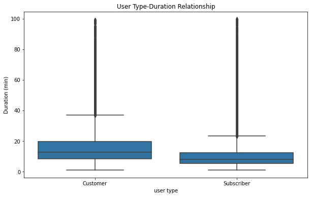

```python
#from the duration_min histogram plotted earlier, most of the outlier are between 100 - 1000
#I will use 100 as my borderline and see how it looks

#visualisation
plt.figure(figsize=(10,6))
data = dfClean.query('duration_min < 100')
sns.boxplot(data = data, x = 'user_type', y = 'duration_min', color = base_color)
plt.xlabel('user type')
plt.ylabel('Duration (min)')
plt.title('User Type-Duration Relationship');
```

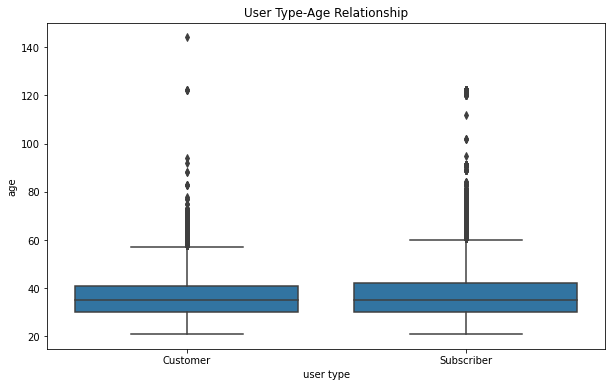

```python
#question to chek the age distribution of the users

#visualisation
plt.figure(figsize=(10,6))
sns.boxplot(data = dfClean, x='user_type', y='Age', color = base_color)
plt.xlabel('user type')
plt.ylabel('age')
plt.title('User Type-Age Relationship');
```

Observation The median age distribution of the users seems about the same. The oldest user is also a customer

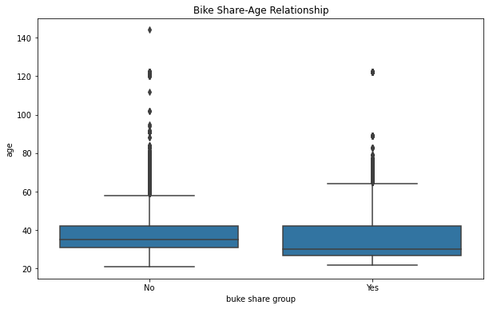

```python
#question to chek the age distribution of people that shared their bike trips

#visualisation
plt.figure(figsize=(10,6))
sns.boxplot(data = dfClean, x='bike_share_for_all_trip', y='Age', color = base_color)
plt.xlabel('buke share group')
plt.ylabel('age')
plt.title('Bike Share-Age Relationship');
```

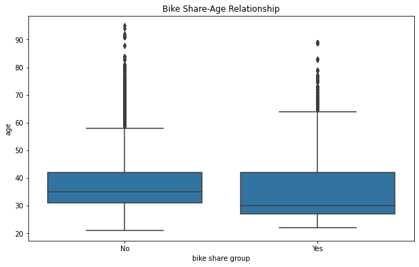

```python
#removing the outliers
data = dfClean[~outliers]
#visualisation
plt.figure(figsize=(10,6))
sns.boxplot(data = data, x='bike_share_for_all_trip', y='Age', color = base_color)
plt.xlabel('bike share group')
plt.ylabel('age')
plt.title('Bike Share-Age Relationship');
```

Observation The median age of the yes group is about 30 while that of the no group is about 35. The yes age distribution is more skewed to the right in comparison to the no group

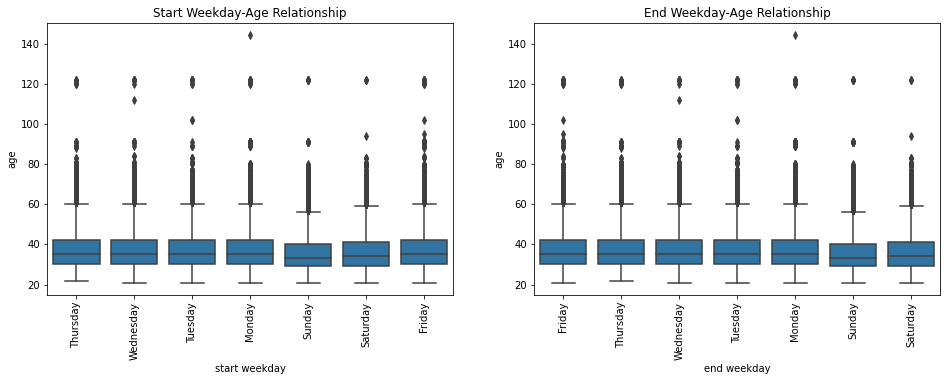

```python
#question to check the age distribution and the start and end days of the bike rides

#Visualisation
# Two plots in one figure
plt.figure(figsize = [16, 5])
base_color = sns.color_palette()[0]

#left plot: start day
plt.subplot(1, 2, 1)
ax1 = sns.boxplot(data = dfClean, y='Age', x ='start_weekday_name', color=base_color)
plt.xticks(rotation = 90);
plt.xlabel('start weekday')
plt.ylabel('age')
plt.title('Start Weekday-Age Relationship');

#right plot: end day
plt.subplot(1, 2, 2)
sns.boxplot(data = dfClean, y ='Age', x ='end_weekday_name', color=base_color)
plt.xticks(rotation = 90)
plt.ylim(ax1.get_ylim()); # set y-axis limits to be same as left plot
plt.xlabel('end weekday')
plt.ylabel('age')
plt.title('End Weekday-Age Relationship');
```

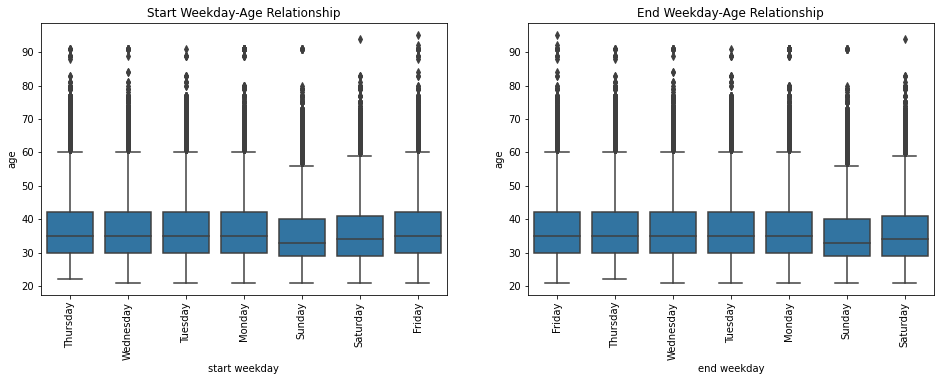

```python
#To get a clearer look, I removed the outliers, ages above 100

#Visualisation
# Two plots in one figure
plt.figure(figsize = [16, 5])
base_color = sns.color_palette()[0]

data = dfClean[~outliers]
#left plot: start day
plt.subplot(1, 2, 1)
ax1 = sns.boxplot(data = data, y='Age', x ='start_weekday_name', color = base_color)
plt.xticks(rotation = 90);
plt.xlabel('start weekday')
plt.ylabel('age')
plt.title('Start Weekday-Age Relationship')

#right plot: end day
plt.subplot(1, 2, 2)
sns.boxplot(data = data, y ='Age', x ='end_weekday_name', color = base_color)
plt.xticks(rotation = 90)
plt.ylim(ax1.get_ylim()); # set y-axis limits to be same as left plot
plt.xlabel('end weekday')
plt.ylabel('age')
plt.title('End Weekday-Age Relationship');
```

Observation The median age of people that started and ended their trips on sundays is reduced compared to the rest of the weekdays Maybe younger people prefer riding on sundays

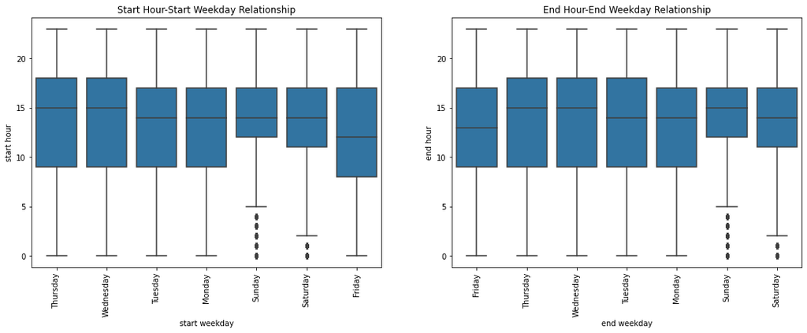

```python
#Question to compare the start and end hours with the start and end weekdays

#Visualisation
# Two plots in one figure
plt.figure(figsize = [18, 6])
base_color = sns.color_palette()[0]

data = dfClean[~outliers]
#left plot: start day
plt.subplot(1, 2, 1)
ax1 = sns.boxplot(data = data, y='start_hour', x ='start_weekday_name', color = base_color)
plt.xticks(rotation = 90);
plt.xlabel('start weekday')
plt.ylabel('start hour')
plt.title('Start Hour-Start Weekday Relationship')

#right plot: end day
plt.subplot(1, 2, 2)
sns.boxplot(data = data, y ='end_hour', x ='end_weekday_name', color = base_color)
plt.xticks(rotation = 90)
plt.ylim(ax1.get_ylim()); # set y-axis limits to be same as left plot
plt.xlabel('end weekday')
plt.ylabel('end hour')
plt.title('End Hour-End Weekday Relationship');
```

Observation Sunday and saturday have outliers

```python
# question - to check average trip duration for each user type

sub = dfClean[dfClean['user_type'] == 'Subscriber'].duration_min.mean()
cust = dfClean[dfClean['user_type'] == 'Customer'].duration_min.mean()
print(sub, cust)
```

```
10.675855083993271 21.844268381021383
```

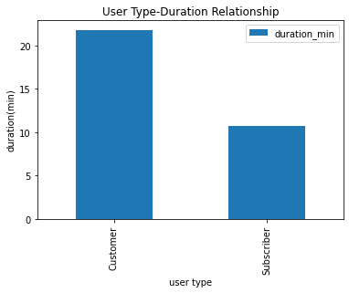

```python
#visualisation
user = dfClean[['user_type', 'duration_min']].groupby('user_type').mean().plot(kind = 'bar')
plt.xlabel('user type')
plt.ylabel('duration(min)')
plt.title('User Type-Duration Relationship');
```

Observation The average duration a customer spends on a bike trip is about twice the duration a subscriber would spend

```python
#question to group the duration spent based on gender
dfClean['member_gender'].value_counts()
```

```
Male      130500
Female     40805
Other       3647
Name: member_gender, dtype: int64
```

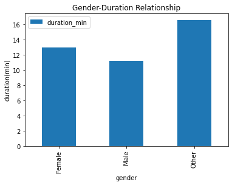

```python
#visualisation
dfClean[['member_gender', 'duration_min']].groupby('member_gender').mean().plot(kind = 'bar')
plt.xlabel('gender')
plt.ylabel('duration(min)')
plt.title('Gender-Duration Relationship');
```

Observation Males spend less time on average, probably because they are generally physically stronger than females. The other gender on average spend more time

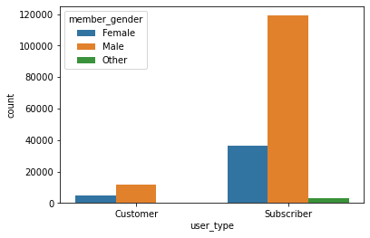

```python
#Question to check the distribution of user types based on the genders

#Visualisation
sns.countplot(data = dfClean, x = 'user_type', hue = 'member_gender');
```

Observation The customers are just males and females, males are more

The subscribers is made of the other gender group and is largely populated by males

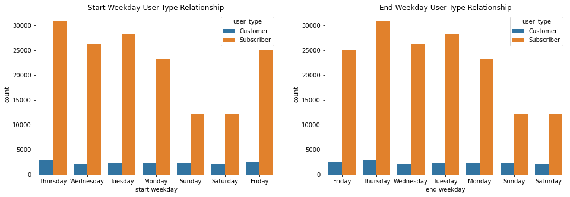

```python
#Question to check if user type relates with start and end days of trips in any way

#visualisation
plt.figure(figsize = [16, 5])

# left plot: start day
plt.subplot(1, 2, 1)
ax1 = sns.countplot(data = dfClean, hue = 'user_type', x = 'start_weekday_name')
plt.xlabel('start weekday')
plt.ylabel('count')
plt.title('Start Weekday-User Type Relationship');

# right plot: end day
plt.subplot(1, 2, 2)
sns.countplot(data = dfClean, hue = 'user_type', x = 'end_weekday_name')
plt.ylim(ax1.get_ylim()); # set y-axis limits to be same as left plot
plt.xlabel('end weekday')
plt.ylabel('count')
plt.title('End Weekday-User Type Relationship');
```

Observation Customers and subscribers alike prefer thursday as their start and end day The number of subscribers ridng on saturdays and sundays are reduced while it is increased during the week

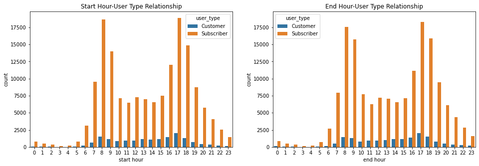

```python
#Question to check if user type relates with start and end days of trips in any way

#visualisation
plt.figure(figsize = [16, 5])

# left plot: start day
plt.subplot(1, 2, 1)
ax1 = sns.countplot(data = dfClean, hue = 'user_type', x = 'start_hour')
plt.xlabel('start hour')
plt.ylabel('count')
plt.title('Start Hour-User Type Relationship')

# right plot: end day
plt.subplot(1, 2, 2)
sns.countplot(data = dfClean, hue = 'user_type', x = 'end_hour')
plt.ylim(ax1.get_ylim()); # set y-axis limits to be same as left plot
plt.xlabel('end hour')
plt.ylabel('count')
plt.title('End Hour-User Type Relationship');
```

Observation Most subscribers prefer early morning (8am) and evening rides(5pm). Customers do not have representation at the ealy hours of the day probably because the larger percentage of the users are subscribers

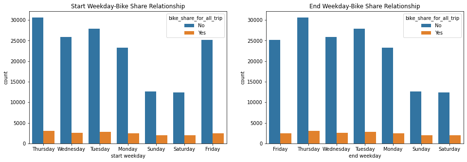

```python
#Question to check if start and end days has any bearing on bike trip sharing or not

#visualisation
plt.figure(figsize = [16, 5])

# left plot: start day
plt.subplot(1, 2, 1)
ax1 = sns.countplot(data = dfClean, hue = 'bike_share_for_all_trip', x = 'start_weekday_name')
plt.xlabel('start weekday')
plt.ylabel('count')
plt.title('Start Weekday-Bike Share Relationship')

# right plot: end day
plt.subplot(1, 2, 2)
sns.countplot(data = dfClean, hue = 'bike_share_for_all_trip', x = 'end_weekday_name')
plt.ylim(ax1.get_ylim()); # set y-axis limits to be same as left plot
plt.xlabel('end weekday')
plt.ylabel('count')
plt.title('End Weekday-Bike Share Relationship');
```

Observation It seems the highest number of yes was on a thursday probably because many users prefer riding on thursday, and lowest number of no was on saturday and sunday. The people that did not share the trip on saturday and sunday reduced probably because they were all rushing to do something else on a weekend and because less number of subscribers ride on weekends

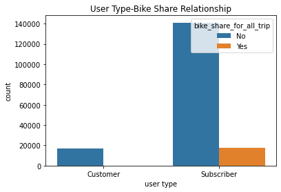

```python
#Question to check the realionship between the bike sharing and user types

#visualisation
sns.countplot(data = dfClean, hue = 'bike_share_for_all_trip', x = 'user_type')
plt.xlabel('user type')
plt.ylabel('count')
plt.title('User Type-Bike Share Relationship');
```

Observation The only people that shared (yes group) were all subscribers, although a larger percentage of the, didnt share

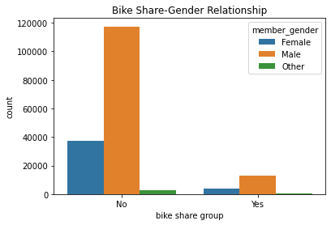

```python
#Question to check the realionship between the bike sharing and gender

#visualisation
sns.countplot(data = dfClean, x = 'bike_share_for_all_trip', hue = 'member_gender');
plt.xlabel('bike share group')
plt.ylabel('count')
plt.title('Bike Share-Gender Relationship');
```

Observation Males have the highest number in both groups, most probably because in this dataset, males are more represented

## Bivariate Exploration

Key Findings Being a subscriber projects a possibility of sharing trips. The customers are just males and females. The average duration a customer spends on a bike trip is about twice the duration a subscriber would spend Males spend less time on average, probably because they are generally physically stronger than females. Some young people are noticed to spend more time while older people are noticed to spend less time on their rides. Customers and subscribers alike prefer thursday as their start and end day The number of subscribers ridng on saturdays and sundays are reduced while it is increased during the week

## Multivariate

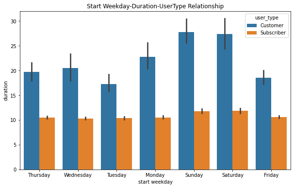

```python
#question to check the daily duration of trips for each type of user

#visualistion
plt.figure(figsize=(10,6))
sns.barplot(data = dfClean, x= 'start_weekday_name', y='duration_min', hue='user_type')

plt.xlabel('start weekday')
plt.ylabel('duration')
plt.title('Start Weekday-Duration-UserType Relationship');
```

Observation On weekends, customers spend more time on their trips

```python
#question to check the distribution of gender based on age and the duration spent on trips
dfClean['member_gender'].value_counts()
```

```
Male      130500
Female     40805
Other       3647
Name: member_gender, dtype: int64
```

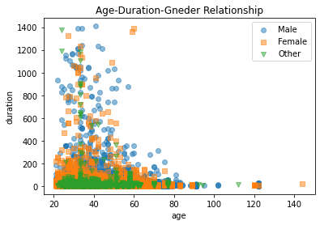

```python
#visualisation
genderMarkers = [['Male', 'o'], ['Female', 's'], ['Other', 'v']]

for gender, marker in genderMarkers:
    dfG = dfClean[dfClean['member_gender'] == gender]
    plt.scatter(data = dfG, y = 'duration_min', x = 'Age', marker = marker, alpha = 0.5)
plt.legend(['Male','Female', 'Other'])

plt.xlabel('age')
plt.ylabel('duration')
plt.title('Age-Duration-Gneder Relationship');
```

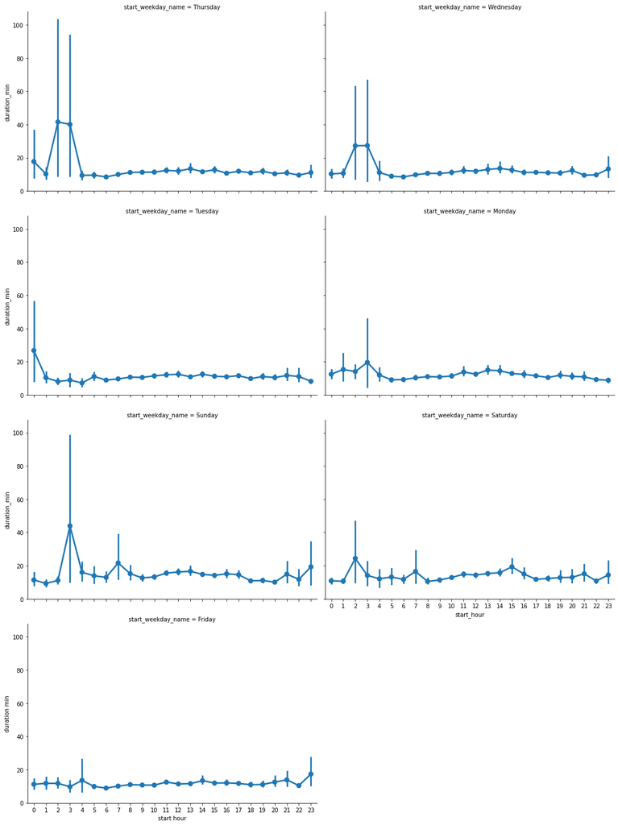

```python
bin_edges = np.arange(0, dfClean['start_weekday'].max()+1, 1)
g=sns.FacetGrid(data = dfClean, col='start_weekday_name', col_wrap = 2, height = 5, aspect = 1.5)
g.map(sns.pointplot,'start_hour', 'duration_min')

plt.xlabel('start hour')
plt.ylabel('duration min')
```

Observation Theres is an increse in the duration spent on riding between 2 and 3 hours of the day for monday, wednesday, thursday, saturday and sunday, while Tuesday peaks at 12am. It seems people like spending more time on riding in the middle of the night compared to during the day

```python
dfClean.to_csv('fordgobike_clean.csv', index=False)
```